# Lebron James App

August 5, 2018

## Introducing the Application

My application is simple. My goal in creating it was to easily visualize game-by-game statistics of NBA players by taking statistics from Basketball-Reference.com. Basketball-Reference is a website that has statistics for every player who has ever played in the NBA. They have simple statistics like points and rebounds and even more advanced analytic stats.

For the sake of this project, I chose Lebron James's 2013-2014 statistics. In that season, he played in 77/82 games which gives a lot of data points to play with.

## Application Code

The following code is the main part of the server.R file which plots the statistic in each game played as well as the mean of the statistic for the season. For this demonstration, I will show points.

```r
df <- select(lebron, G, PTS)
meanstat <- mean(df[,2], na.rm=T)
plot(df, pch=19)
abline(h = meanstat, lwd=2, col="red")
title("Lebron James 2013-2014 Statistics by Game")
```

Where the mean of his points for the year is 27.13

## Example Plot

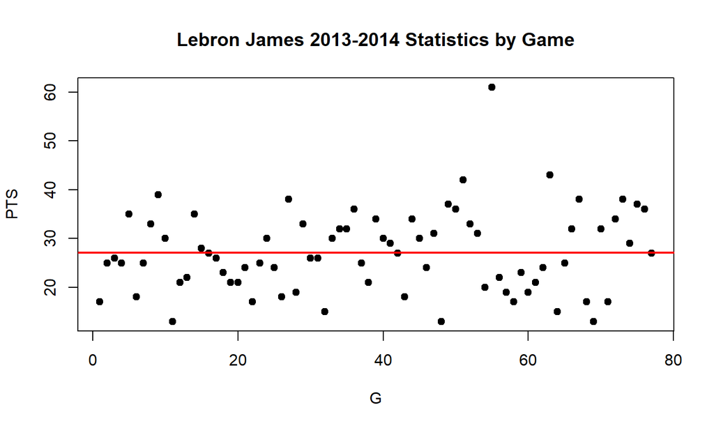

## Future Plans

As of right now, the application is pretty limited as it only shows stats for one player in one season. With more time I could hopefully be able to add many more players' stats over many more seasons and potentially even compare two players' game by game statistics and averages. That, of course, is a more complicated thing to do but is still worthwhile.

Some possibilities for improving on this would be to use ggplot2 or plotly to show the data rather than R's base graphics. Plotly especially would be a good one because of how interactive it can be.